# SJoshuaM GitHub Repository Table Of Contents

Josh M.

2021-02-05

*Note: This page is under construction. Please excuse the typos, grammar mistakes, and incomplete content.*

### road_trips: My Road Trips and Road Tripping Plans

This project maps out my past road trips and future road tripping plans. I aspire to see 108 metropolitan areas across the United States and adjacent areas of Canada. I built this project for my own happiness - a poster sized version of this project’s visualization is pinned to my wall. However, it does also serve as a good skill-sharpening exercise, as it entails:

- Working with geographic data scattered across multiple KML files
- Calculating map projections and arrangements for four discrete geographies
- Generating a “data dashboard” style visualization

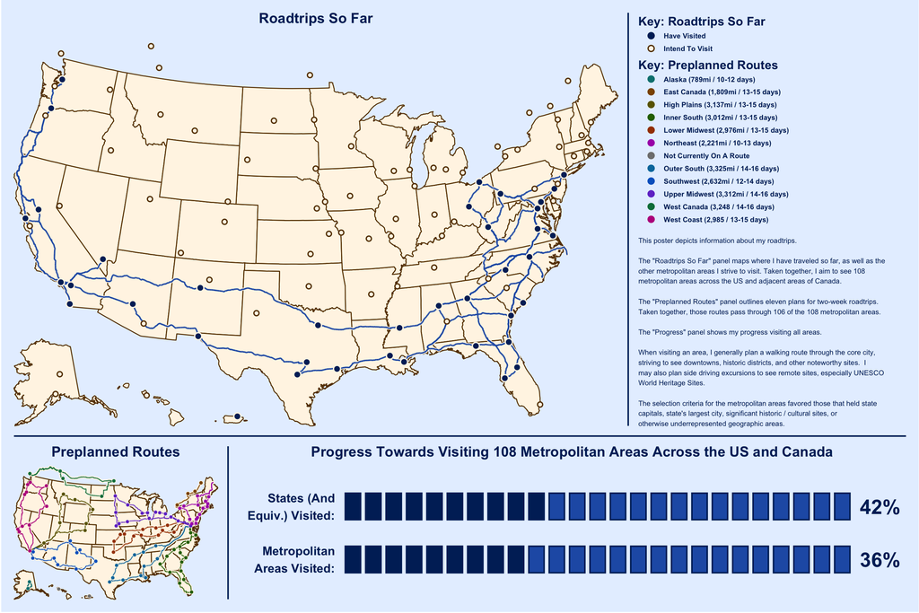

### travel_suggestions: Travel Suggestions for the Aspiring World Traveler

This project suggests a slate of travel suggestions for an American, based on a number of “ease of travel” and “point of interest” criteria. I built this project as a skill sharpening exercise, as it entails:

- Pulling data from three APIs
- Fusing eight datasets without a reliable primary key
- Engineering multi-criteria decision-making code to generate the slate of recommendations
- Visualizing the project story, approach, and results

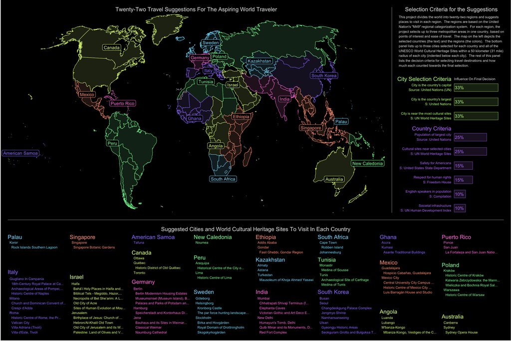

### Displaying Crowded Scatterplots

### R Programming “Textbook” - Materials From My Introductory R Programming Class